### 2. Use the Descriptors in the Demographic data sheet to perform Discriminant Analysis type analysis (use any supervised learning technique) based on segments obtained in Step 1 and personify /describe each segment.

#### Solution:

#### Loading the tables, then merging the output from the first table to create the sheet which contains the group number,

```r
#discrimcluster <- read.csv("C://Users//AKANKSHA//Desktop//ISB CBA//Marketing Analytics//DiscriminantAnalysis.csv", header = TRUE, sep = ",")
#Newtable=merge(discrimcluster, partdataWithClusterMember, by = "Respondents")
#write.csv(Newtable,file="discrimtableWithGroup.csv")

discrimtableWithGroup <- read.csv("C://Users//AKANKSHA//Desktop//ISB CBA//Marketing Analytics//MergedTable.csv", header = TRUE, sep = ",")
```

#### Viweing the tables,

```r
head(discrimtableWithGroup)
```

```
##   ClusterNumber Weekly.consumption Age..1.7. Income..1.7. Education..1.6.
## 1             2                  2         5            4               5
## 2             2                  9         6            7               3
## 3             2                  6         4            6               6
## 4             2                 24         5            7               5
## 5             2                  2         2            3               5
## 6             2                  8         5            5               5
##   Sex..M.1.
## 1         1
## 2         1
## 3         1
## 4         2
## 5         2
## 6         2
```

```r
dim(discrimtableWithGroup)
```

```
## [1] 317   6
```

#### Using the descriptors provided to perform LDA,

```r
#install.packages("psych")
library(psych)
```

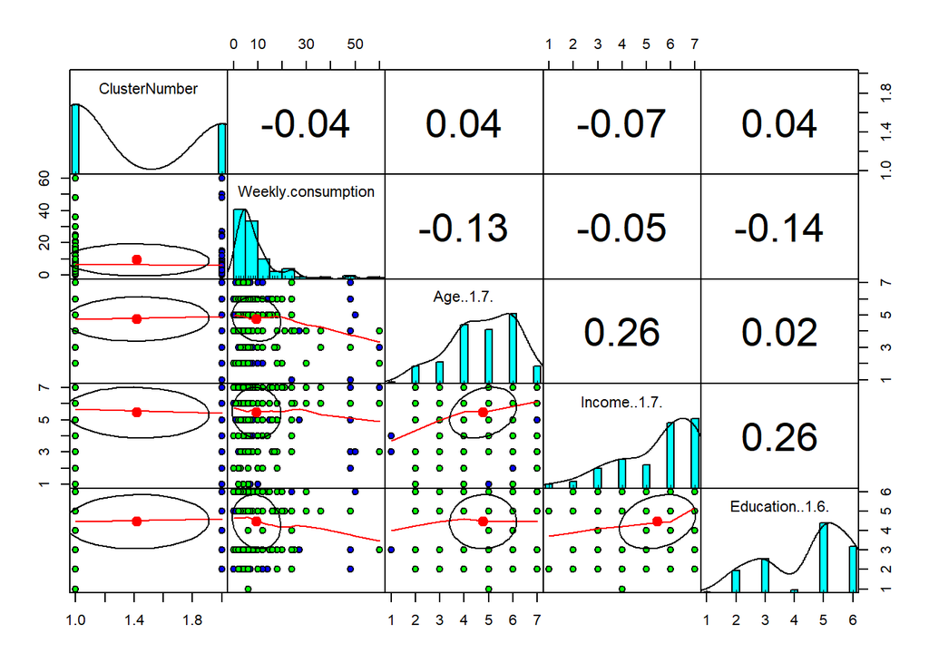

```r
pairs.panels(discrimtableWithGroup[1:5], gap = 0, bg = c("green","blue")[discrimtableWithGroup$ClusterNumber], pch = 21)
```

#### The purpose of linear discriminant analysis (LDA) in our question is to find the linear combinations of the original variables that provides seperate clusters. In our case, we can see that there are two groups which exist. Let’s perform the LDA now,

```r
#Data Partition
Initial <- sample(2, nrow(discrimtableWithGroup), replace = TRUE, prob = c(.6, .4))
Trainset <- discrimtableWithGroup[Initial == 1, ]
Testset <- discrimtableWithGroup[Initial == 2, ]

library(MASS)
LinFunction <- lda(ClusterNumber ~ ., Trainset)
LinFunction
```

```
## Call:
## lda(ClusterNumber ~ ., data = Trainset)
##
## Prior probabilities of groups:
##         1         2
## 0.5944444 0.4055556
##
## Group means:
##   Weekly.consumption Age..1.7. Income..1.7. Education..1.6. Sex..M.1.
## 1           10.68224  4.850467     5.495327        4.345794  1.084112
## 2           10.54795  5.041096     5.287671        4.410959  1.164384
##
## Coefficients of linear discriminants:
##                            LD1
## Weekly.consumption  0.02140966
## Age..1.7.           0.47843820
## Income..1.7.       -0.36757526
## Education..1.6.     0.20880595
## Sex..M.1.           2.43640130
```

```r
attributes(LinFunction)
```

```
## $names
##  [1] "prior"   "counts"  "means"   "scaling" "lev"     "svd"     "N"
##  [8] "call"    "terms"   "xlevels"
##
## $class
## [1] "lda"
```

#### The above shows the degree of seperation that can be achieved. And the group means also gives us an idea how the demographic features looks for both the clusters.So, from the above we can see that Cluster 1 has higher consumption than Cluster 2. We can also see that Cluster 2 is more educated than Cluster 1 so it makes logical sense .It can also be seen from Q1 that Cluster 2 liked Rich bodied beer. The age of both the groups is almost similar.

```r
PredFunc<- predict(LinFunction, Trainset)
PredFunc
```

```
## $class
##   [1] 2 1 1 1 1 1 1 1 1 1 2 1 1 1 1 1 1 2 1 1 1 2 1 1 1 2 2 1 1 1 1 2 1 1 1
##  [36] 1 1 1 1 1 1 1 1 2 1 1 1 1 1 1 1 1 1 1 2 1 1 1 2 2 2 1 1 2 1 1 1 1 1 1
##  [71] 2 1 2 1 1 1 2 1 1 2 2 1 1 1 1 1 1 1 2 1 1 1 1 1 1 1 1 1 1 1 1 1 1 1 1
## [106] 1 1 1 1 1 1 1 1 1 1 1 1 1 1 1 1 1 1 1 1 1 1 1 1 1 1 1 1 2 1 1 1 1 2 1
## [141] 1 1 1 1 1 1 1 1 1 2 1 1 1 1 1 1 1 1 1 1 1 1 2 1 1 1 2 1 1 1 1 1 1 1 1
## [176] 1 1 2 1 1
## Levels: 1 2
##
## $posterior
##             1         2
## 5   0.4510077 0.5489923
## 8   0.6151942 0.3848058
## 11  0.6224095 0.3775905
## 13  0.6178911 0.3821089
```

[output cut: 359 more lines]

```r
par("mar")
```

```
## [1] 5.1 4.1 4.1 2.1
```

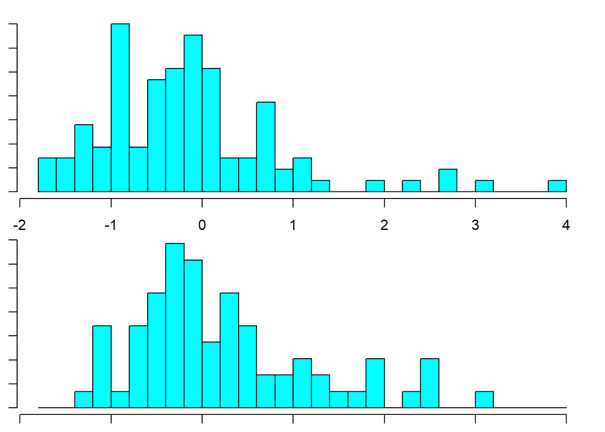

```r
par(mar=c(1,1,1,1))
ldahist(data = PredFunc$x[,1], g = Trainset$ClusterNumber)
```

#### The above shows the histogram of different groups. Let’s try to classify observations based on LDA using klar,

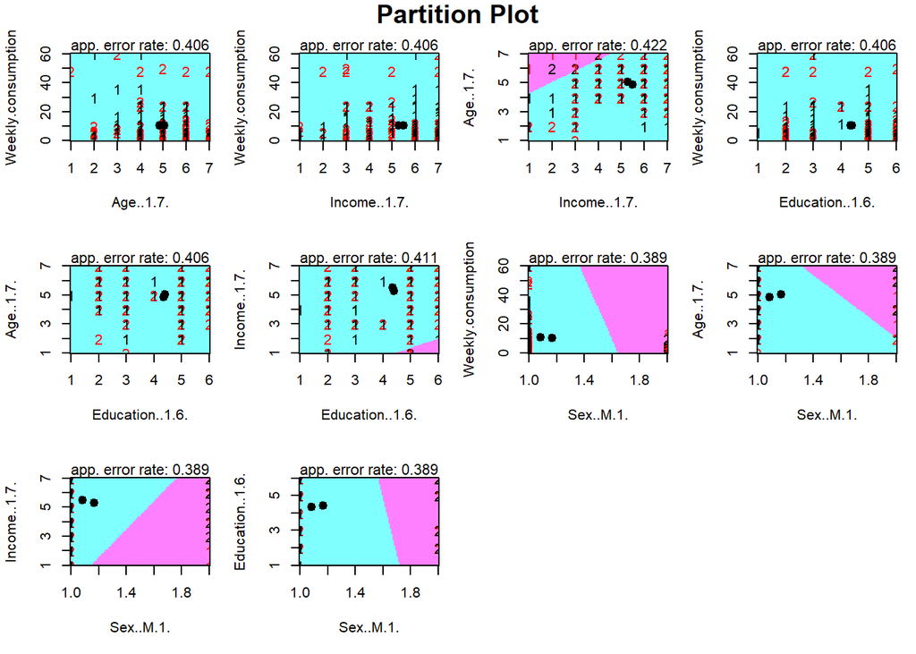

```r
#install.packages("klaR")
library(klaR)
partimat(factor(ClusterNumber) ~ ., data = Trainset, method = "lda")
```

#### Drawing the confusion matrix next to estimate how is our accuracy,

```r
#Confusion Matrix and Accuracy

PredFunc1 <- predict(LinFunction, Trainset)$class
Table1 <- table(Predicted = PredFunc1, Actual = Trainset$ClusterNumber)
Table1
```

```
##          Actual
## Predicted  1  2
##         1 97 58
##         2 10 15
```

```r
sum(diag(Table1))/ sum(Table1)
```

```
## [1] 0.6222222
```